# wines

raghad

January 13, 2019

## Statistical Summary

### Structure of the dataset

```
##        X          fixed.acidity   volatile.acidity  citric.acid
##  Min.   :   1.0   Min.   : 4.60   Min.   :0.1200   Min.   :0.000
##  1st Qu.: 400.5   1st Qu.: 7.10   1st Qu.:0.3900   1st Qu.:0.090
##  Median : 800.0   Median : 7.90   Median :0.5200   Median :0.260
##  Mean   : 800.0   Mean   : 8.32   Mean   :0.5278   Mean   :0.271
##  3rd Qu.:1199.5   3rd Qu.: 9.20   3rd Qu.:0.6400   3rd Qu.:0.420
##  Max.   :1599.0   Max.   :15.90   Max.   :1.5800   Max.   :1.000
##  residual.sugar     chlorides       free.sulfur.dioxide
##  Min.   : 0.900   Min.   :0.01200   Min.   : 1.00
##  1st Qu.: 1.900   1st Qu.:0.07000   1st Qu.: 7.00
##  Median : 2.200   Median :0.07900   Median :14.00
##  Mean   : 2.539   Mean   :0.08747   Mean   :15.87
##  3rd Qu.: 2.600   3rd Qu.:0.09000   3rd Qu.:21.00
##  Max.   :15.500   Max.   :0.61100   Max.   :72.00
##  total.sulfur.dioxide    density             pH          sulphates
##  Min.   :  6.00       Min.   :0.9901   Min.   :2.740   Min.   :0.3300
##  1st Qu.: 22.00       1st Qu.:0.9956   1st Qu.:3.210   1st Qu.:0.5500
##  Median : 38.00       Median :0.9968   Median :3.310   Median :0.6200
##  Mean   : 46.47       Mean   :0.9967   Mean   :3.311   Mean   :0.6581
##  3rd Qu.: 62.00       3rd Qu.:0.9978   3rd Qu.:3.400   3rd Qu.:0.7300
##  Max.   :289.00       Max.   :1.0037   Max.   :4.010   Max.   :2.0000
##     alcohol         quality
##  Min.   : 8.40   Min.   :3.000
##  1st Qu.: 9.50   1st Qu.:5.000
##  Median :10.20   Median :6.000
##  Mean   :10.42   Mean   :5.636
##  3rd Qu.:11.10   3rd Qu.:6.000
##  Max.   :14.90   Max.   :8.000
```

```
##    Min. 1st Qu.  Median    Mean 3rd Qu.    Max.
##   3.000   5.000   6.000   5.636   6.000   8.000
```

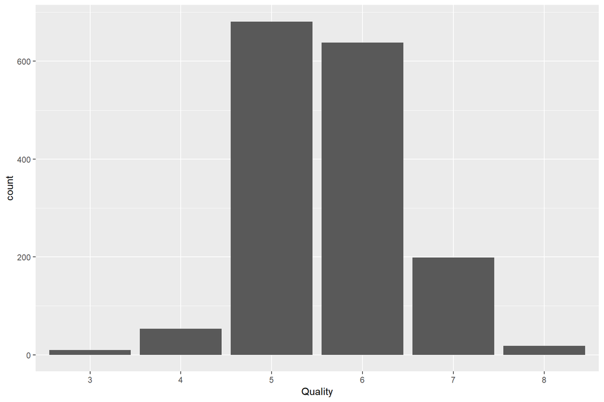

# Univariate Plots Section

### acidity for the red wines

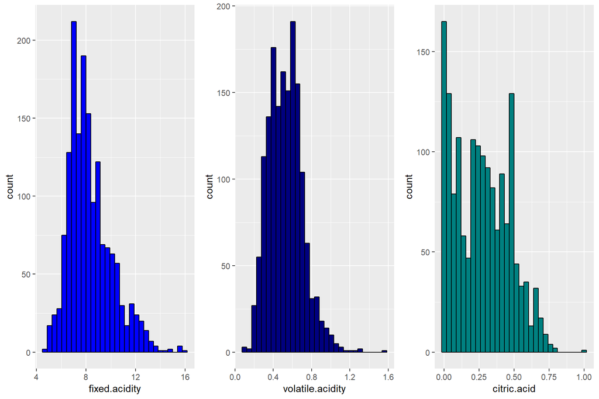

### Calculate total acidity

To calculate sum of all acids in the red wines, we create a new variable called total.acidity

```
## [1]  8.10  8.68  8.60 12.04  8.10  8.06
```

### Find number of zeroes in citric.acid

```
## [1] 132
```

We found that 132 observations have zero values.

```
##    Min. 1st Qu.  Median    Mean 3rd Qu.    Max.
##   0.900   1.900   2.200   2.539   2.600  15.500
```

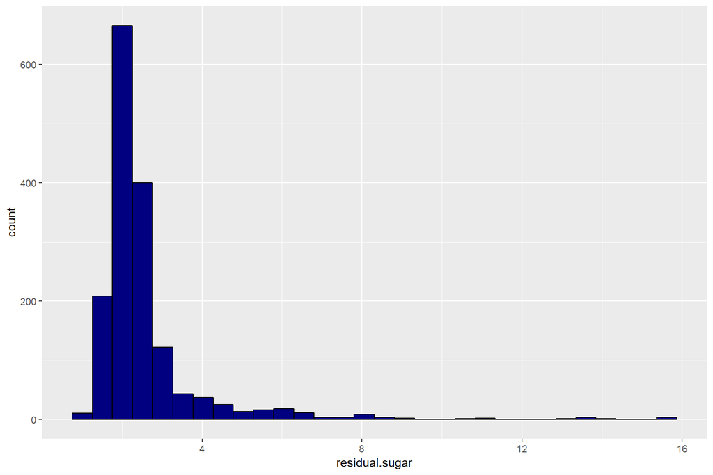

The distribution of residual sugar is right skewed . There are many small bars on the right side of the main peak.and we see it has an extreme outliers.

```
##    Min. 1st Qu.  Median    Mean 3rd Qu.    Max.
## 0.01200 0.07000 0.07900 0.08747 0.09000 0.61100
```

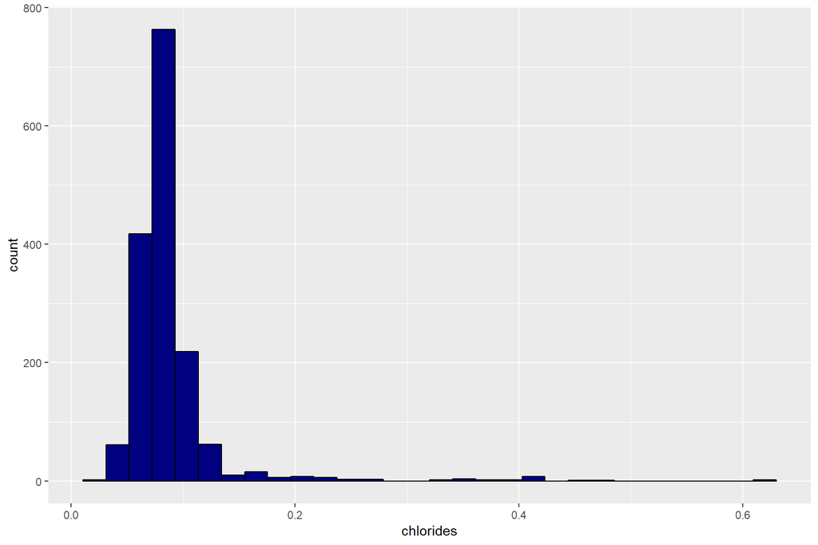

The distribution is normal around its main peak but has a very long right tail, with small counts of wines with values until 0.611.and we see it has an outliers.

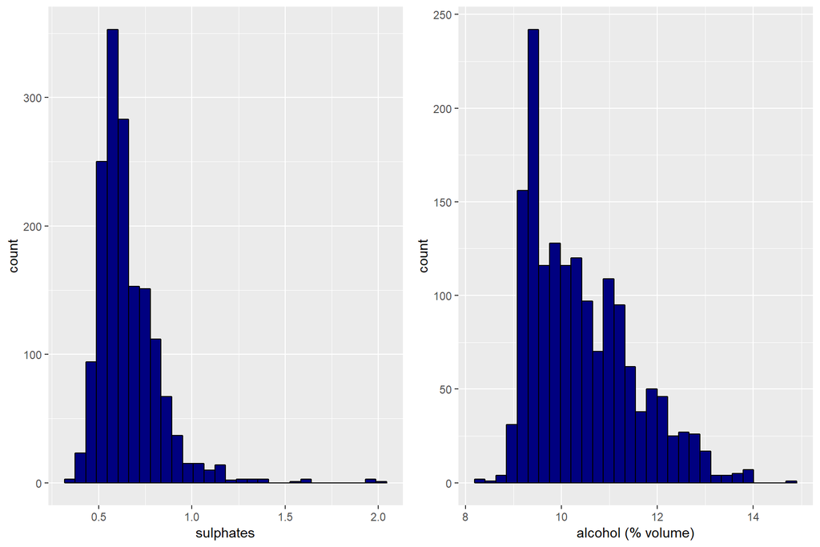

we see The distribution of sulphates and alcohol are right skewed. and there are Some outliers on the right tail.

```
##    Min. 1st Qu.  Median    Mean 3rd Qu.    Max.
##   2.740   3.210   3.310   3.311   3.400   4.010
```

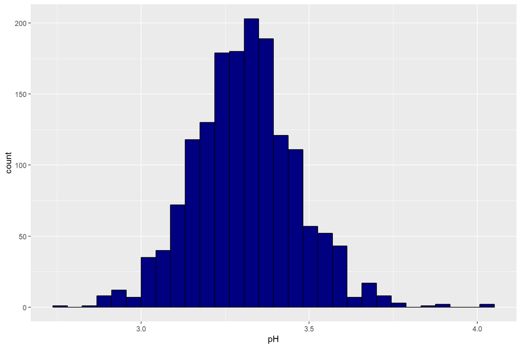

```
##    Min. 1st Qu.  Median    Mean 3rd Qu.    Max.
##  0.9901  0.9956  0.9968  0.9967  0.9978  1.0037
```

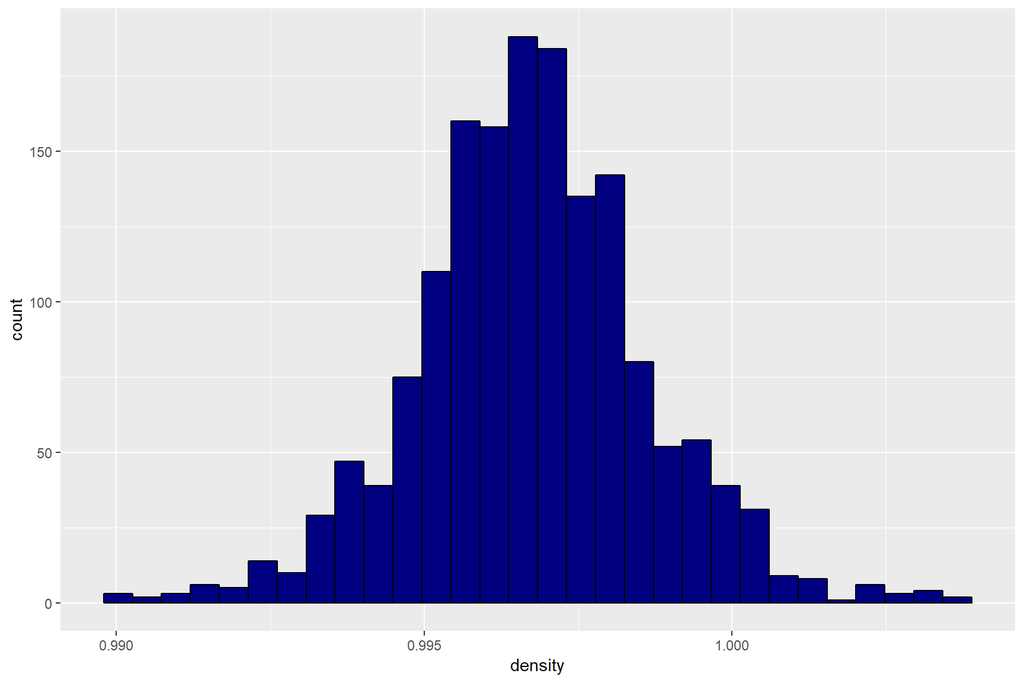

## Univariate Analysis

### What is the structure of your dataset?

```
## 'data.frame':    1599 obs. of  14 variables:
##  $ X                   : int  1 2 3 4 5 6 7 8 9 10 ...
##  $ fixed.acidity       : num  7.4 7.8 7.8 11.2 7.4 7.4 7.9 7.3 7.8 7.5 ...
##  $ volatile.acidity    : num  0.7 0.88 0.76 0.28 0.7 0.66 0.6 0.65 0.58 0.5 ...
##  $ citric.acid         : num  0 0 0.04 0.56 0 0 0.06 0 0.02 0.36 ...
##  $ residual.sugar      : num  1.9 2.6 2.3 1.9 1.9 1.8 1.6 1.2 2 6.1 ...
##  $ chlorides           : num  0.076 0.098 0.092 0.075 0.076 0.075 0.069 0.065 0.073 0.071 ...
##  $ free.sulfur.dioxide : num  11 25 15 17 11 13 15 15 9 17 ...
##  $ total.sulfur.dioxide: num  34 67 54 60 34 40 59 21 18 102 ...
##  $ density             : num  0.998 0.997 0.997 0.998 0.998 ...
##  $ pH                  : num  3.51 3.2 3.26 3.16 3.51 3.51 3.3 3.39 3.36 3.35 ...
##  $ sulphates           : num  0.56 0.68 0.65 0.58 0.56 0.56 0.46 0.47 0.57 0.8 ...
##  $ alcohol             : num  9.4 9.8 9.8 9.8 9.4 9.4 9.4 10 9.5 10.5 ...
##  $ quality             : int  5 5 5 6 5 5 5 7 7 5 ...
##  $ total.acidity       : num  8.1 8.68 8.6 12.04 8.1 ...
```

#### What is/are the main feature(s) of interest in your dataset?

our main objective is to conclude quality. So, it’s the main feature.

#### What other features in the dataset do you think will help support your investigation into your feature(s) of interest?

density and pH are also normally distributed. So, i think these two can help support our analysis.

#### Did you create any new variables from existing variables in the dataset?

yes , i create total.acidity to calculate sum of all acids.

#### Of the features you investigated, were there any unusual distributions?

#### Did you perform any operations on the data to tidy, adjust, or change the form

#### of the data? If so, why did you do this?

There were no unusual distributions, no missing values and no need to adjust the data.

## Bivariate Plots Section

### Boxplot of quality

#### acidity vs. Quality

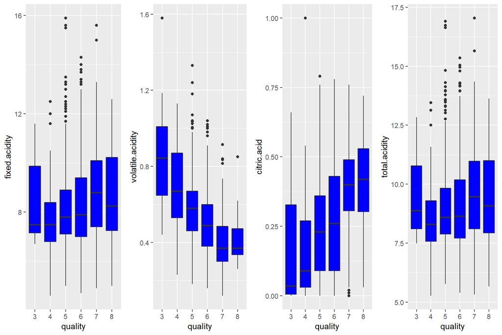

We see in the first graph in the left, a very slight upward trend of higher quality with higher fixed acidity. And we see a drop of acidity from 7 to the 8 quality. in the second graph, we can see a more obvious trend. Lower volatile acidity seems to mean higher wine quality. in the third graph, we can see Higher citric acid seems to mean a higher quality wine.

#### Residual Sugar vs. Quality

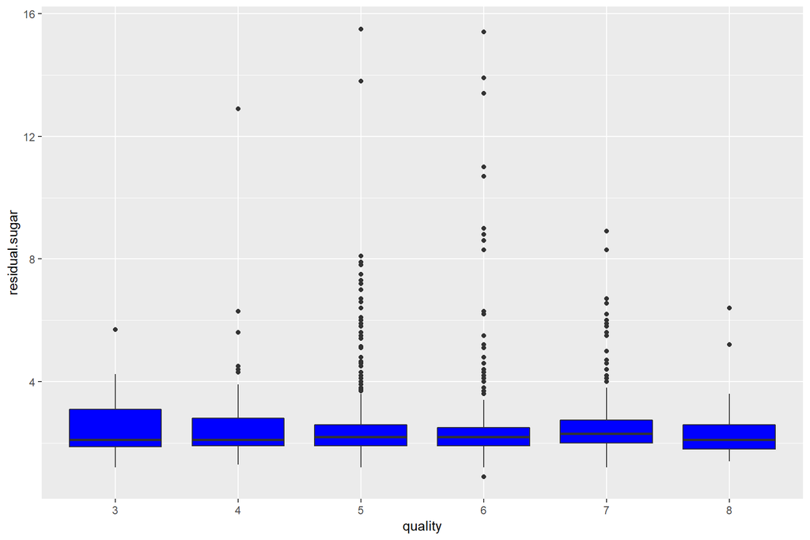

we see Residual sugar seems to have a low impact in the quality of the wine.

#### Chlorides vs. Quality

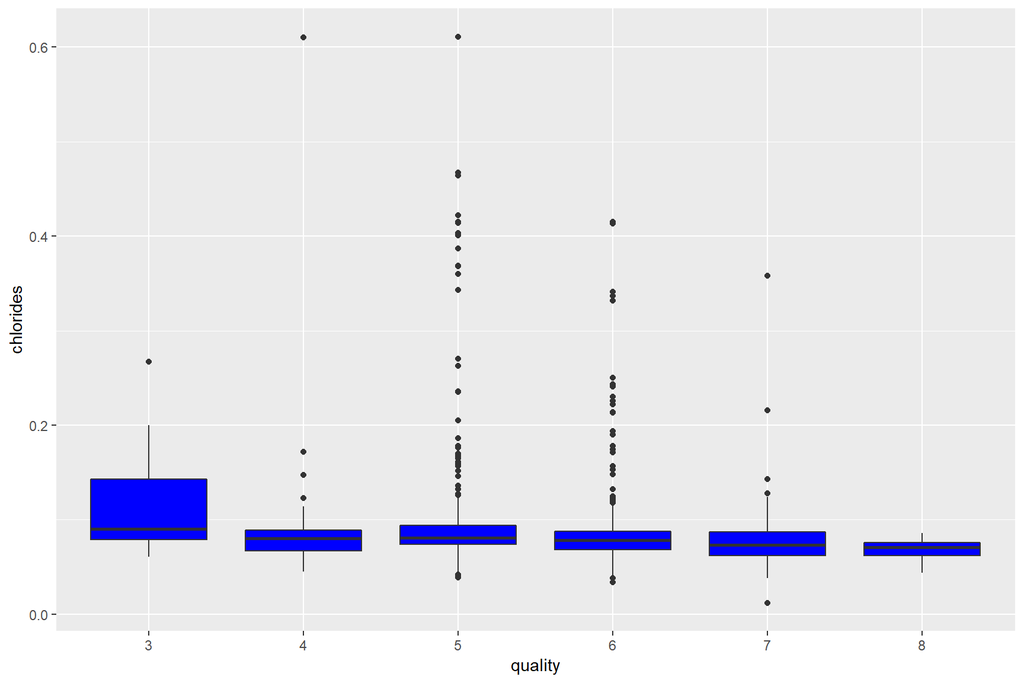

we can see a slight relation. Less chlorides means higher quality.

#### (Free sulfur dioxide,Total sulfur dioxide) vs. Quality

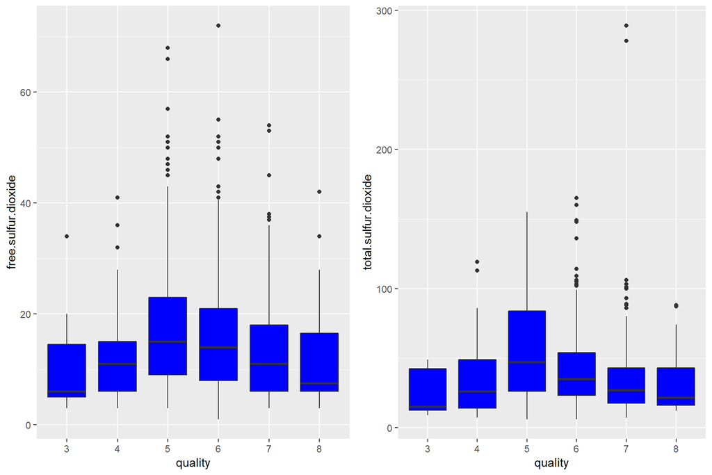

we see The middle quality seem to have higher free sulfur dioxide and total sulfur dioxide than the low and high quality.

#### Density vs. Quality

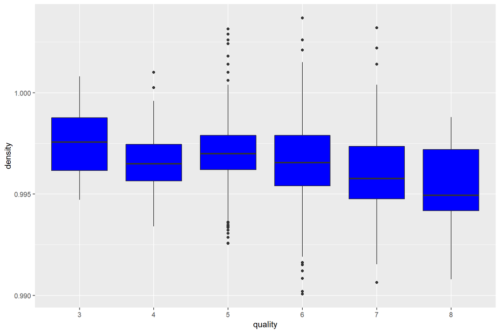

we can see a Lower density means higher quality.

#### pH vs. Quality

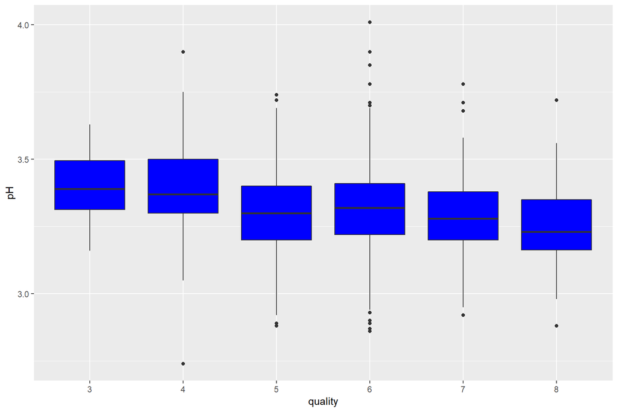

There seems to be a trend of higher quality with lower pH.

#### Sulphates vs. Quality

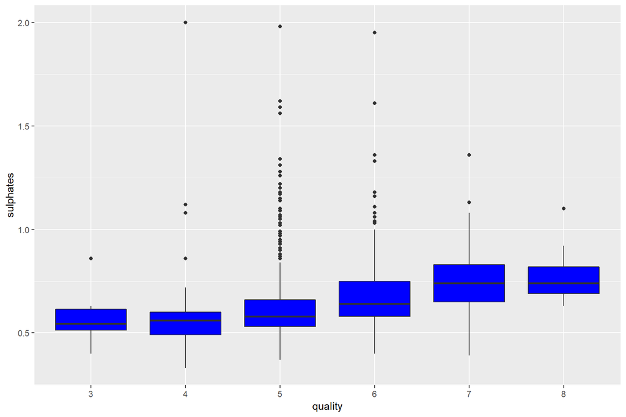

we can see a Higher sulphates concentration means higher quality.

#### Alcohol vs. Quality

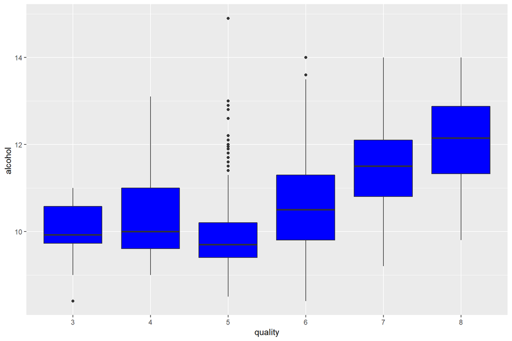

Besides the small downward bump in the quality class 5, the higher the alcohol content, the higher quality the wines get.

#### Acidity and pH

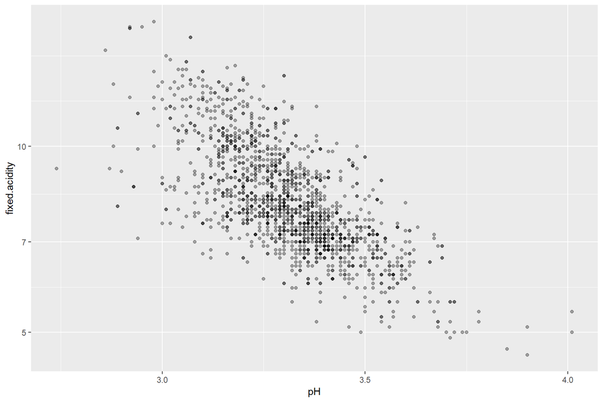

As expected the pH increases with the lower amount of acids. Fixed acidity accounts for most acids present in the wine.

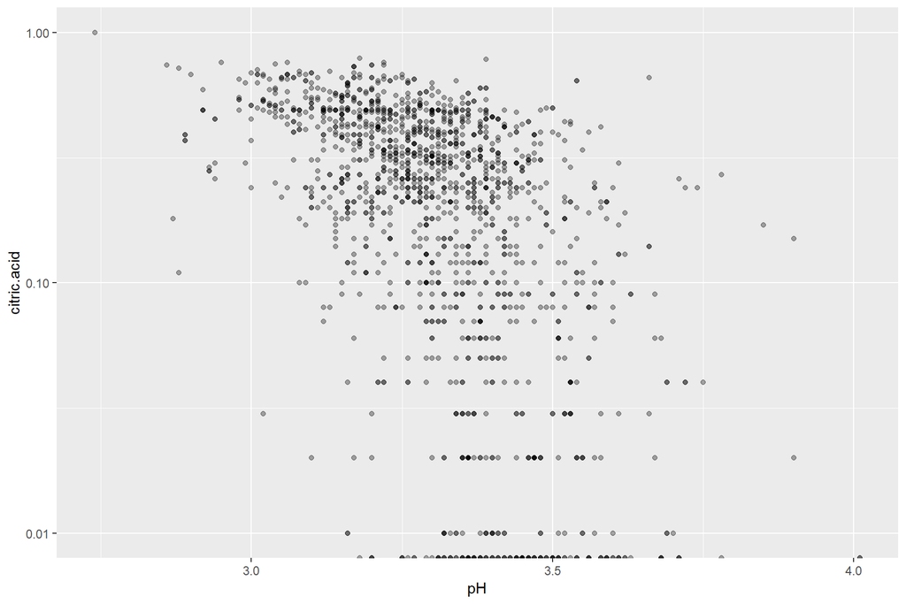

A similar relation is seen with the citric acid , But since the citric acid is at lower concentrations, the relation is not so strong.

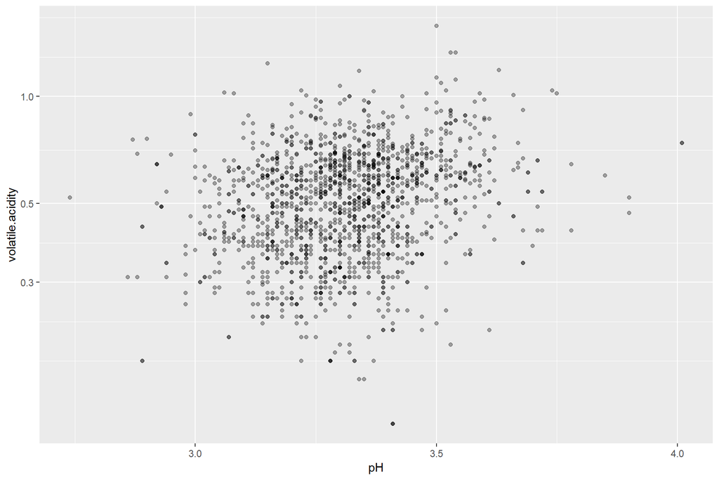

The volatile acidity seems to have either no relation with the pH or a slight positive correlation.

Correlation coefficient:

```
##
##  Pearson's product-moment correlation
##
## data:  pH and log10(volatile.acidity)
## t = 9.1468, df = 1597, p-value < 2.2e-16
## alternative hypothesis: true correlation is not equal to 0
## 95 percent confidence interval:
##  0.1760195 0.2691923
## sample estimates:
##       cor
## 0.2231154
```

The correlation coefficient shows a weak positive correlation of volatile.acidity with the pH.

### Correlations with quality

[output not shown]

# Bivariate Analysis

#### Talk about some of the relationships you observed in this part of the investigation. How did the feature(s) of interest vary with other features in the dataset?

The wine quality is higher has stronger relationship with the volatile acidity, citric acid, sulphates and alcohol content.

#### Did you observe any interesting relationships between the other features (not the main feature(s) of interest)?

I observed the expected relation between the pH and acidity level.

## Multivariate Plots Section

Quality strongly correlates with alcohol and volatile.acidity.

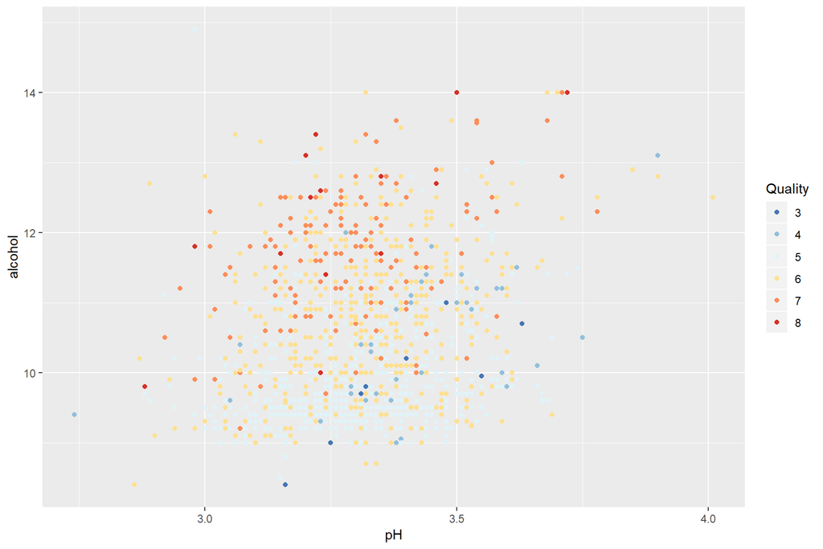

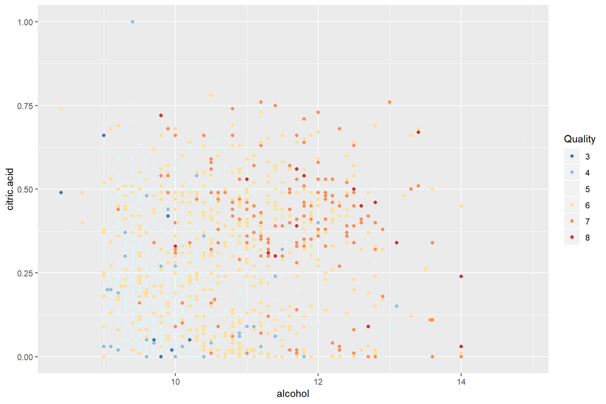

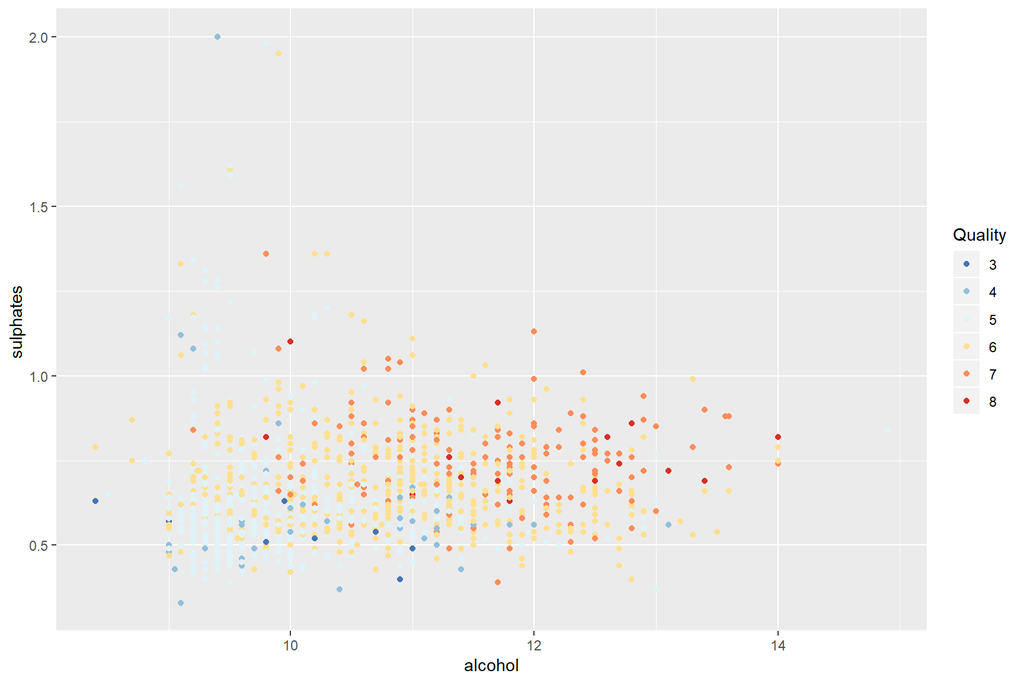

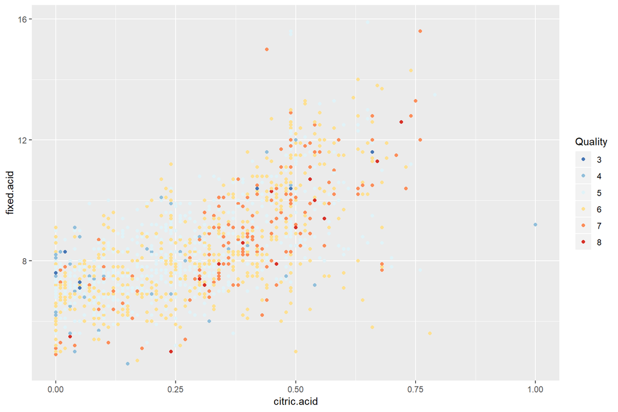

we can see from (fixed.acid,citric.acid) plot,the relation between them is positive , when fixed.acid increases then the citric.acid increase too. when the citric.acid is higher and the fixed.acidity is lower,that means better wines.

and from (alcohol,Sulphates) plot, we can see It looks like Wines with higher alcohol content produce better wine if they have higher level of Sulphates

also in the (Alcohol,citric.acid) plot,the higher citric.acid and higher Alcohol means better wines.

finally in the (Alcohol,pH) plot , we can see the low pH and high Alcohol percentage seems to produce better wines.

## Final Plots and Summary

### Plot One

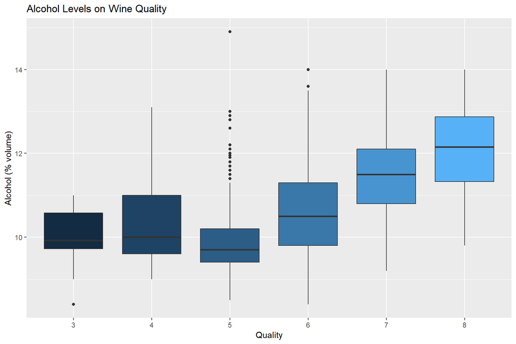

### Description One

As alcohol is highly correlated with the quality, From the above plot, we can see For the quality classes 3 to 5, the effect is limited. but from the quality 5 to 8, we see a sharp increase in the alcohol content. The general trend is that Wines with higher alcohol content are rated higher in quality.

### Plot Two

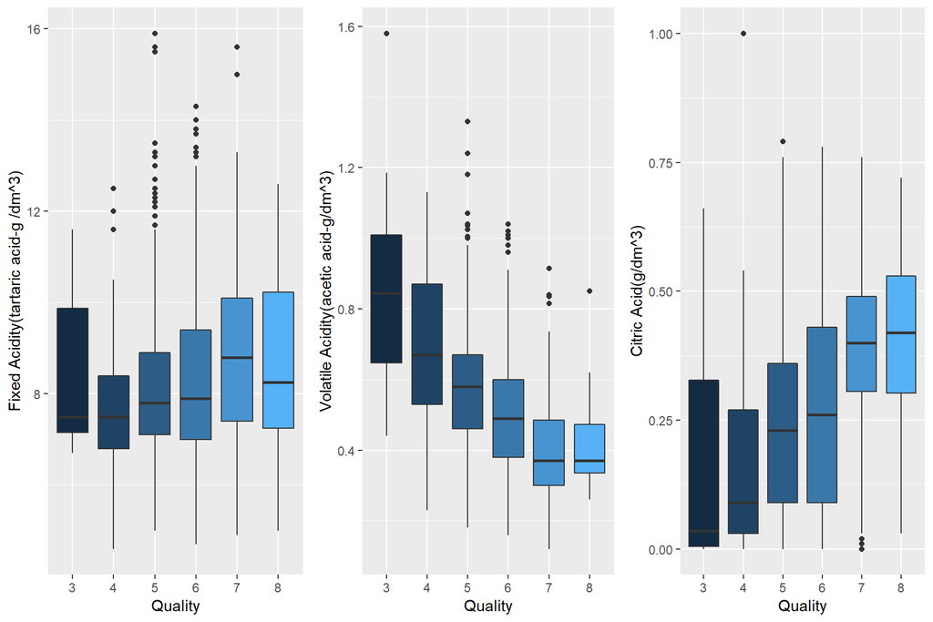

### Plot Three

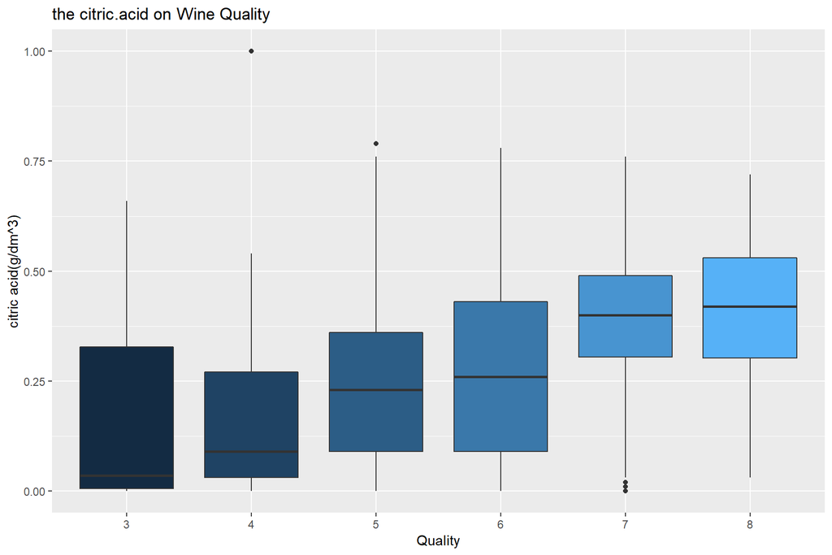

# Reflection

firstly when I was writing for this project, I saw that some wines didn’t have citric acid at all. My first thought was maybe this was bad data or there is missing data. But then I researched about wines. I saw that citric acid actually is added to some wines to increase the acidity.

finally, I can say that Wine quality is a very complex study. Future improvement can be made if more data can be collected on both low-quality and high-quality wine. If the data set has more records on both the low end and high end, the quality of analysis can be improved.